# Ordinal Logistic Regression

Lian

2016年8月18日

## R Markdown

Below are the steps to perform OLR in R: [Reference HTTP](https://www.analyticsvidhya.com/blog/2016/02/multinomial-ordinal-logistic-regression/)

```r
require(foreign)
```

```r
require(ggplot2)
require(MASS)
require(Hmisc)
require(reshape2)
dat <- read.dta("http://www.ats.ucla.edu/stat/data/ologit.dta")
head(dat)
```

```
##             apply pared public  gpa
## 1     very likely     0      0 3.26
## 2 somewhat likely     1      0 3.21
## 3        unlikely     1      1 3.94
## 4 somewhat likely     0      0 2.81
## 5 somewhat likely     0      0 2.53
## 6        unlikely     0      1 2.59
```

Let’s quickly understand the data.

The data set has a dependent variable known as apply. It has 3 levels namely “unlikely”, “somewhat likely”, and “very likely”, coded in 1, 2, and 3 respectively. 3 being highest and 1 being lowest. This situation is best for using ordinal regression because of presence of ordered categories. Pared (0/1) refers to at least one parent has a graduate degree; public (0/1) refers to the type of undergraduate institute.

For building this model, we will be using the polr command to estimate an ordered logistic regression. Then, we’ll specify Hess=TRUE to let the model output show the observed information matrix from optimization which is used to get standard errors.

```r
m <- polr(apply ~ pared + public + gpa, data = dat, Hess=TRUE)
summary(m)
```

```
## Call:
## polr(formula = apply ~ pared + public + gpa, data = dat, Hess = TRUE)
##
## Coefficients:
##           Value Std. Error t value
## pared   1.04769     0.2658  3.9418
## public -0.05879     0.2979 -0.1974
## gpa     0.61594     0.2606  2.3632
##
## Intercepts:
##                             Value   Std. Error t value
## unlikely|somewhat likely     2.2039  0.7795     2.8272
## somewhat likely|very likely  4.2994  0.8043     5.3453
##
## Residual Deviance: 717.0249
## AIC: 727.0249
```

We see the usual regression output coefficient table including the value of each coefficient, standard errors, t values, estimates for the two intercepts, residual deviance and AIC. AIC is the information criteria. Lesser the better.

Now we’ll calculate some essential metrics such as p-Value, CI, Odds ratio

```r
ctable <- coef(summary(m))
ctable
```

```
##                                   Value Std. Error    t value
## pared                        1.04769010  0.2657894  3.9418050
## public                      -0.05878572  0.2978614 -0.1973593
## gpa                          0.61594057  0.2606340  2.3632399
## unlikely|somewhat likely     2.20391473  0.7795455  2.8271792
## somewhat likely|very likely  4.29936315  0.8043267  5.3452947
```

```r
p <- pnorm(abs(ctable[, "t value"]), lower.tail = FALSE) * 2
ctable <- cbind(ctable, "p value" = p)
ctable
```

```
##                                   Value Std. Error    t value      p value
## pared                        1.04769010  0.2657894  3.9418050 8.087072e-05
## public                      -0.05878572  0.2978614 -0.1973593 8.435464e-01
## gpa                          0.61594057  0.2606340  2.3632399 1.811594e-02
## unlikely|somewhat likely     2.20391473  0.7795455  2.8271792 4.696004e-03
## somewhat likely|very likely  4.29936315  0.8043267  5.3452947 9.027008e-08
```

```r
ci <- confint(m)
ci  # confidence intervals
```

```
##             2.5 %    97.5 %
## pared   0.5281768 1.5721750
## public -0.6522060 0.5191384
## gpa     0.1076202 1.1309148
```

```r
exp(coef(m))
```

```
##     pared    public       gpa
## 2.8510579 0.9429088 1.8513972
```

```r
exp(cbind(OR = coef(m), ci))
```

```
##               OR     2.5 %   97.5 %
## pared  2.8510579 1.6958376 4.817114
## public 0.9429088 0.5208954 1.680579
## gpa    1.8513972 1.1136247 3.098490
```

### Interpretation

1. One unit increase in parental education, from 0 (Low) to 1 (High), the odds of “very likely” applying versus “somewhat likely” or “unlikely” applying combined are 2.85 greater .
2. The odds “very likely” or “somewhat likely” applying versus “unlikely” applying is 2.85 times greater .
3. For gpa, when a student’s gpa moves 1 unit, the odds of moving from “unlikely” applying to “somewhat likely” or “very likley” applying (or from the lower and middle categories to the high category) are multiplied by 1.85.

Let’s now try to enhance this model to obtain better prediction estimates.

```r
summary(m)
```

```
## Call:
## polr(formula = apply ~ pared + public + gpa, data = dat, Hess = TRUE)
##
## Coefficients:
##           Value Std. Error t value
## pared   1.04769     0.2658  3.9418
## public -0.05879     0.2979 -0.1974
## gpa     0.61594     0.2606  2.3632
##
## Intercepts:
##                             Value   Std. Error t value
## unlikely|somewhat likely     2.2039  0.7795     2.8272
## somewhat likely|very likely  4.2994  0.8043     5.3453
##
## Residual Deviance: 717.0249
## AIC: 727.0249
```

```r
summary(update(m, method = "probit", Hess = TRUE), digits = 3)
```

```
## Call:
## polr(formula = apply ~ pared + public + gpa, data = dat, Hess = TRUE,
##     method = "probit")
##
## Coefficients:
##         Value Std. Error t value
## pared  0.5981      0.158  3.7888
## public 0.0102      0.173  0.0588
## gpa    0.3582      0.157  2.2848
##
## Intercepts:
##                             Value Std. Error t value
## unlikely|somewhat likely    1.297 0.468      2.774
## somewhat likely|very likely 2.503 0.477      5.252
##
## Residual Deviance: 717.4951
## AIC: 727.4951
```

```r
summary(update(m, method = "logistic", Hess = TRUE), digits = 3)
```

```
## Call:
## polr(formula = apply ~ pared + public + gpa, data = dat, Hess = TRUE,
##     method = "logistic")
##
## Coefficients:
##          Value Std. Error t value
## pared   1.0477      0.266   3.942
## public -0.0588      0.298  -0.197
## gpa     0.6159      0.261   2.363
##
## Intercepts:
##                             Value  Std. Error t value
## unlikely|somewhat likely     2.204  0.780      2.827
## somewhat likely|very likely  4.299  0.804      5.345
##
## Residual Deviance: 717.0249
## AIC: 727.0249
```

```r
summary(update(m, method = "cloglog", Hess = TRUE), digits = 3)
```

```
## Call:
## polr(formula = apply ~ pared + public + gpa, data = dat, Hess = TRUE,
##     method = "cloglog")
##
## Coefficients:
##        Value Std. Error t value
## pared  0.517      0.161   3.202
## public 0.108      0.168   0.643
## gpa    0.334      0.154   2.168
##
## Intercepts:
##                             Value Std. Error t value
## unlikely|somewhat likely    0.871 0.455      1.912
## somewhat likely|very likely 1.974 0.461      4.287
##
## Residual Deviance: 719.4982
## AIC: 729.4982
```

Let’s add interaction terms here

```r
head(predict(m, dat, type = "p"))
```

```
##    unlikely somewhat likely very likely
## 1 0.5488310       0.3593310  0.09183798
## 2 0.3055632       0.4759496  0.21848725
## 3 0.2293835       0.4781951  0.29242138
## 4 0.6161224       0.3126888  0.07118879
## 5 0.6560149       0.2833901  0.06059505
## 6 0.6609240       0.2797117  0.05936430
```

```r
addterm(m, ~.^2, test = "Chisq")
```

```
## Single term additions
##
## Model:
## apply ~ pared + public + gpa
##              Df    AIC     LRT Pr(Chi)
## <none>          727.02
## pared:public  1 727.81 1.21714  0.2699
## pared:gpa     1 728.98 0.04745  0.8276
## public:gpa    1 728.60 0.42953  0.5122
```

```r
m2 <- stepAIC(m, ~.^2)
```

```
## Start:  AIC=727.02
## apply ~ pared + public + gpa
##
##                Df    AIC
## - public        1 725.06
## <none>            727.02
## + pared:public  1 727.81
## + public:gpa    1 728.60
## + pared:gpa     1 728.98
## - gpa           1 730.67
## - pared         1 740.60
##
## Step:  AIC=725.06
## apply ~ pared + gpa
##
##             Df    AIC
## <none>         725.06
## + pared:gpa  1 727.02
## + public     1 727.02
## - gpa        1 728.79
## - pared      1 738.60
```

```r
m2
```

```
## Call:
## polr(formula = apply ~ pared + gpa, data = dat, Hess = TRUE)
##
## Coefficients:
##     pared       gpa
## 1.0457078 0.6042468
##
## Intercepts:
##    unlikely|somewhat likely somewhat likely|very likely
##                    2.176269                    4.271585
##
## Residual Deviance: 717.0638
## AIC: 725.0638
```

```r
summary(m2)
```

```
## Call:
## polr(formula = apply ~ pared + gpa, data = dat, Hess = TRUE)
##
## Coefficients:
##        Value Std. Error t value
## pared 1.0457     0.2656   3.937
## gpa   0.6042     0.2539   2.379
##
## Intercepts:
##                             Value  Std. Error t value
## unlikely|somewhat likely    2.1763 0.7671     2.8370
## somewhat likely|very likely 4.2716 0.7922     5.3924
##
## Residual Deviance: 717.0638
## AIC: 725.0638
```

```r
m2$anova
```

```
## Stepwise Model Path
## Analysis of Deviance Table
##
## Initial Model:
## apply ~ pared + public + gpa
##
## Final Model:
## apply ~ pared + gpa
##
##
##       Step Df   Deviance Resid. Df Resid. Dev      AIC
## 1                              395   717.0249 727.0249
## 2 - public  1 0.03891634       396   717.0638 725.0638
```

```r
anova(m, m2)
```

```
## Likelihood ratio tests of ordinal regression models
##
## Response: apply
##                  Model Resid. df Resid. Dev   Test    Df   LR stat.
## 1          pared + gpa       396   717.0638
## 2 pared + public + gpa       395   717.0249 1 vs 2     1 0.03891634
##     Pr(Chi)
## 1
## 2 0.8436145
```

```r
m3 <- update(m, Hess=TRUE)
pr <- profile(m3)
confint(pr)
```

```
##             2.5 %    97.5 %
## pared   0.5281772 1.5721695
## public -0.6522008 0.5191415
## gpa     0.1076189 1.1309092
```

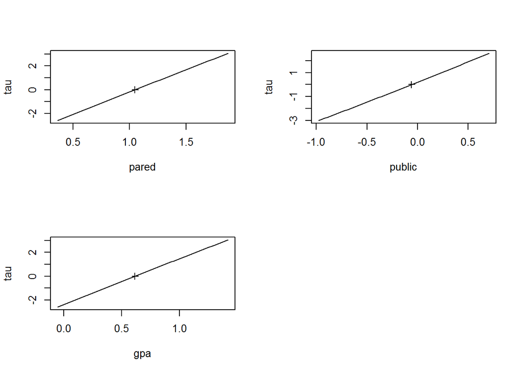

```r
plot(pr)
```

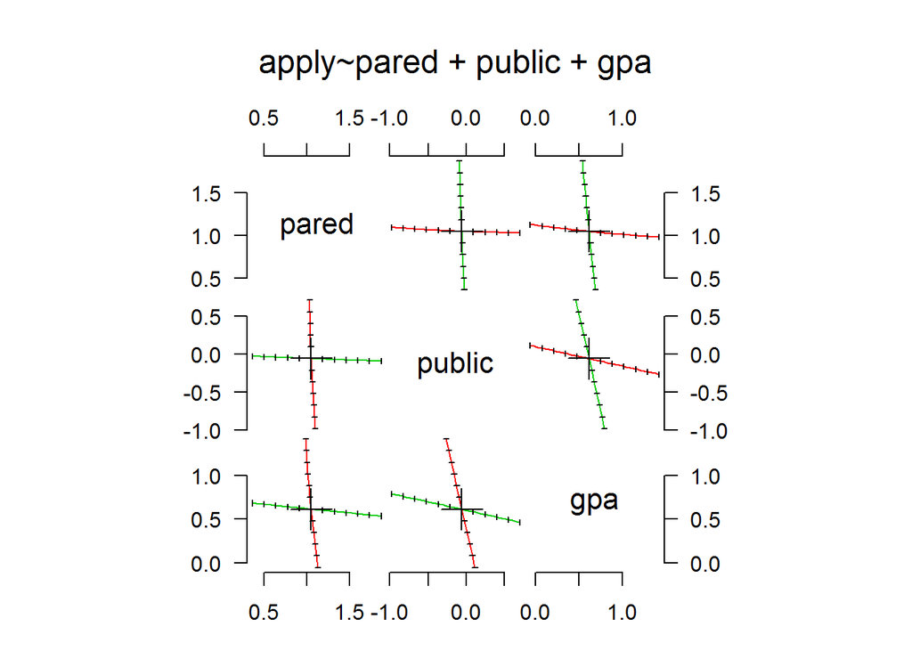

```r
pairs(pr)
```